# US Incareration Analysis

## Introduction

Within this project, I’ve decided to look at the general state of incarceration within the United States, taking an astute focus within the African American populations as well as a deep dive into Santa Clara County, California. The reason why I’ve chosen this region in particular is because this is my home, where I originally came from before coming to Seattle. You may also notice I’ve chosen to only look at the time frame after the year 2000. This is because this will more accurately depict patterns of inequality that goes on in the modern time.

## Chart 1

The reason I included this chart is because I thought it would show the different progressions of race within the prisons of Santa Clara County. Despite black incarceration rates being the higest nationwide, Within the Santa Clara County the Latinx population actually maintains the highest jail population, but this is mainly due to a much higher latinx population within Santa Clara County. One interesting note is that as a whole, incarceration populations take a large decrease around 2010.

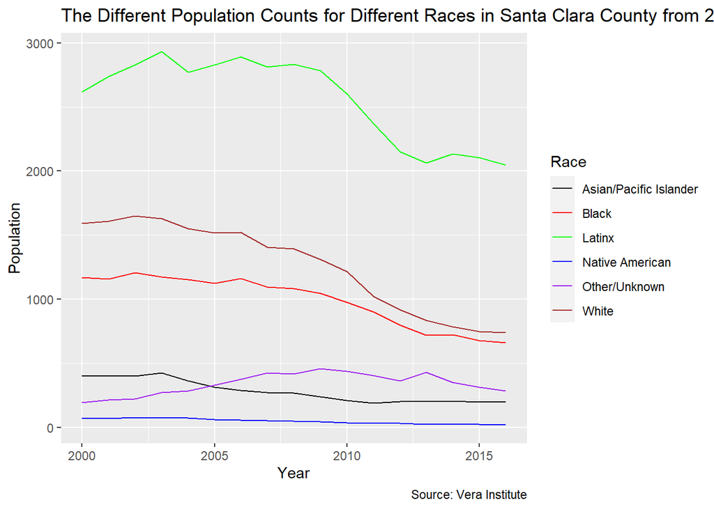

## Chart 2

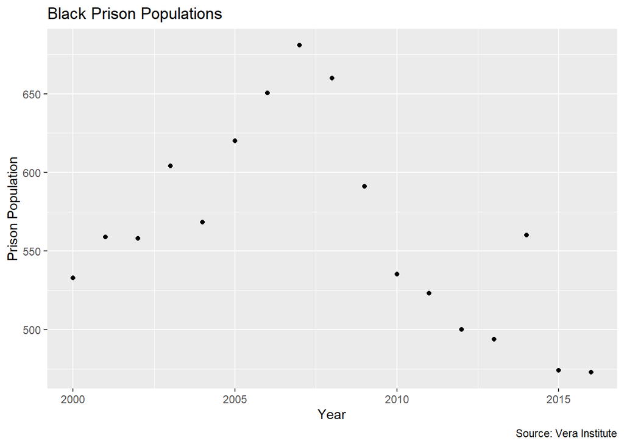

## Chart 3

For chart 3, I felt the most simplest map to look at would be to look at the total prison population by state. Unsurprisingly, the states with the highest population came out as the states with the highest jail population. What did shock me was definiitely some smaller states suchas North Carolina and Tennessee have numbers that rival even bigger states such as Pennsylvania and New York.

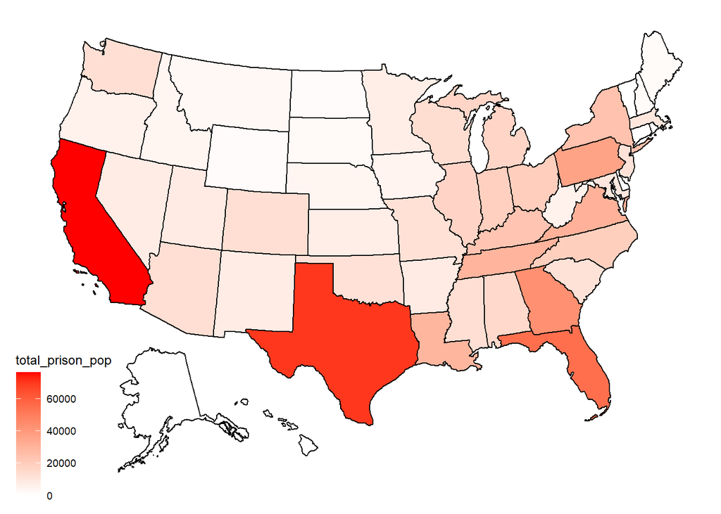